# R Notebook

### 5) Ejercicio:

Se usarán los datos de lecturas anteriores de house_rent. El modelo a ajustar es:
$$rent \sim size$$
. Es decir nos gustaría poder ajustar el precio solamente con el tamaño de la casa.

#### 5.1) Ajusta la regresión lineal y determina si la $\beta_0$, $\beta_1$ y $R^2$ son significativas:

```r
library(tidymodels)
library(readr)
library(moments)
library(tseries)
library(tidyverse)
house_rent <-
  read_csv("house_rent.csv") %>%
  select(Rent, Size) %>%
  set_names(c("rent", "size"))
lm_fit <-
  linear_reg() %>%
  fit(rent~size, data = house_rent)

tidy(lm_fit)
```

| term | estimate | std.error | statistic | p.value |
| --- | --- | --- | --- | --- |
| (Intercept) | -14282.44072 | 1883.269447 | -7.583854 | 4.011535e-14 |
| size | 50.93164 | 1.628011 | 31.284574 | 1.690873e-195 |

```r
glance(lm_fit)
```

| r.squared | adj.r.squared | sigma | statistic | p.value | df | logLik | AIC | BIC | deviance | df.residual | nobs |
| --- | --- | --- | --- | --- | --- | --- | --- | --- | --- | --- | --- |
| 0.1710242 | 0.1708495 | 71121.9 | 978.7246 | 1.690873e-195 | 1 | -59756.31 | 119518.6 | 119538 | 2.39967e+13 | 4744 | 4746 |

Aunque $R^2 = 0.17$, vemos que el valorp es cercano a 0, por lo que podemos rechazar $H_0: P^2= 0$. Entonces si es significativa. La misma conclusión se puede derivar de $\beta_0$ y $\beta_1$.

Los residuos los podemos calcular:

```r
yhat <- predict(lm_fit, new_data = house_rent %>% select(size))
residuo <- house_rent$rent-yhat
```

#### 5.2) Realiza un histograma para mostrar la distribución de los errores de la regresión

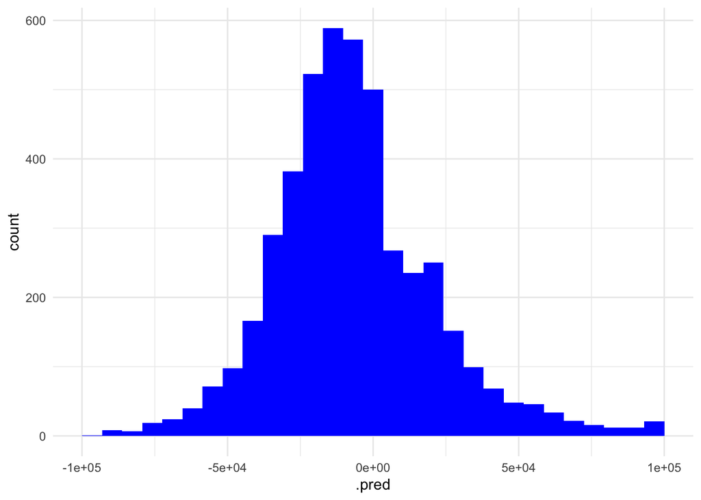

```r
residuo %>%
  ggplot(aes(x = .pred)) +
  geom_histogram(fill = "blue")+
  theme_minimal()+
  theme(legend.position = "none")+
  xlim(-100000,100000)
```

Se puede observar que hay un ligero sesgo a la derecha, pero realmente con la gráfica no podemos concluir

#### 5.3) Realiza un boxplot para mostrar la distribución de los errores de la regresión

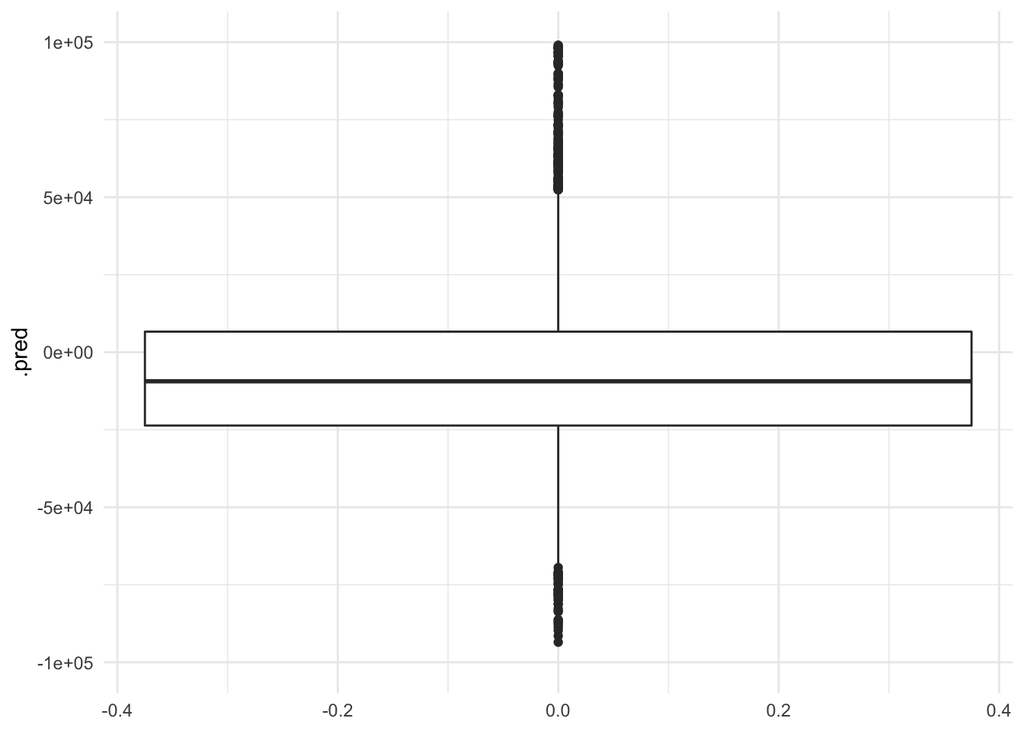

```r
residuo %>%
  ggplot(aes(x = .pred))+
  geom_boxplot()+
  coord_flip()+
  theme_minimal()+
  theme(legend.position = "none")+
  xlim(-100000,100000)
```

En esta gráfica es un poco más complicado determinar si hay un sesgo o incluso si corresponde a una varianza de una distribución normal

#### 5.4) Realiza un qqplot para mostrar la distribución de los errores de la regresión

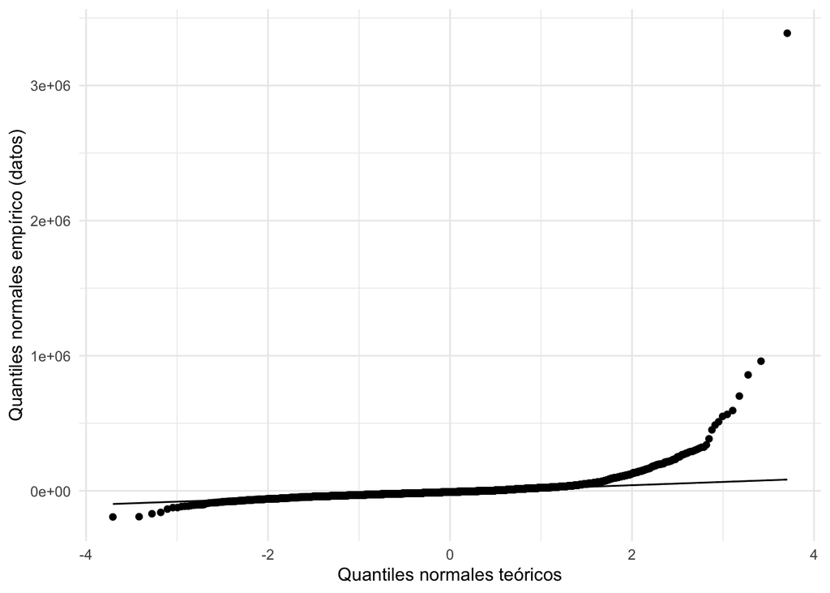

```r
residuo %>%
  ggplot(aes(sample = .pred))+
  stat_qq() + stat_qq_line()+
  theme_minimal()+
  theme(legend.position = "none")+
  labs(x = "Quantiles normales teóricos",
       y = "Quantiles normales empírico (datos)")
```

Con la gráfica podemos observar que tiene colas más pesadas que una distribución normal, por lo que probablemente el supuesto de normalidad no se cumpla.

#### 5.5) Realiza una prueba Jarque-Bera para mostrar la distribución de los errores de la regresión

```r
jarque.bera.test(residuo$.pred)
```

```
##
##  Jarque Bera Test
##
## data:  residuo$.pred
## X-squared = 240308034, df = 2, p-value < 2.2e-16
```

Por lo tanto rechazamos que los datos sean normales.